# Apriori

2025-05-16

```
## spc_tbl_ [208,535 × 21] (S3: spec_tbl_df/tbl_df/tbl/data.frame)
##  $ Asist        : num [1:208535] 5 1 4 5 2 5 1 5 5 5 ...
##  $ Añoreg       : num [1:208535] 2015 2016 9 2012 2021 ...
##  $ Caudef       : chr [1:208535] "X959" "X959" "X954" "X599" ...
##  $ Depocu       : num [1:208535] 1 3 5 12 16 5 1 1 5 1 ...
##  $ Depreg       : num [1:208535] 1 3 5 12 16 5 1 1 5 1 ...
##  $ Diaocu       : num [1:208535] 21 18 2 16 21 21 2 18 17 27 ...
##  $ Dnadif       : num [1:208535] 22 3 5 12 16 5 10 1 5 1 ...
##  $ Dredif       : num [1:208535] 1 3 5 12 16 5 1 1 5 1 ...
##  $ Ecidif       : num [1:208535] 1 1 1 1 2 1 2 1 1 1 ...
##  $ Edadif       : num [1:208535] 27 25 26 2 50 31 73 25 23 20 ...
##  $ Mesocu       : num [1:208535] 9 1 2 8 10 5 11 7 6 6 ...
##  $ Mesreg       : num [1:208535] 9 1 2 8 10 5 11 7 6 6 ...
##  $ Mredif       : num [1:208535] 108 302 507 1229 1609 ...
##  $ Ocur         : num [1:208535] 6 1 3 9 1 9 1 5 5 9 ...
##  $ Perdif       : num [1:208535] 3 3 3 3 3 3 3 3 3 3 ...
##  $ Sexo         : num [1:208535] 1 1 1 1 1 1 1 1 1 1 ...
##  $ Mnadif       : chr [1:208535] "2201" "0301" "0507" "1229" ...
##  $ year         : num [1:208535] 2015 2016 2009 2012 2021 ...
##  $ Escodif      : num [1:208535] 3 2 NA 1 5 1 2 4 3 3 ...
##  $ letra_inicial: chr [1:208535] "X" "X" "X" "X" ...
##  $ causa_macro  : chr [1:208535] "Causas externas" "Causas externas" "Causas externas" "Causas externas" ...
##  - attr(*, "spec")=
##   .. cols(
##   ..   Asist = col_double(),
##   ..   Añoreg = col_double(),
##   ..   Caudef = col_character(),
##   ..   Depocu = col_double(),
##   ..   Depreg = col_double(),
##   ..   Diaocu = col_double(),
##   ..   Dnadif = col_double(),
##   ..   Dredif = col_double(),
##   ..   Ecidif = col_double(),
##   ..   Edadif = col_double(),
##   ..   Mesocu = col_double(),
##   ..   Mesreg = col_double(),
##   ..   Mredif = col_double(),
##   ..   Ocur = col_double(),
##   ..   Perdif = col_double(),
##   ..   Sexo = col_double(),
##   ..   Mnadif = col_character(),
##   ..   year = col_double(),
##   ..   Escodif = col_double(),
##   ..   letra_inicial = col_character(),
##   ..   causa_macro = col_character()
##   .. )
##  - attr(*, "problems")=<externalptr>
```

```
##  Sexo           Edadif          Escodif           Depreg          Mesocu
##  1:124500   1      :  8000   1      :105921   1      :54331   7      : 18543
##  2: 84035   83     :  3829   2      : 49355   16     :14143   8      : 18047
##             82     :  3825   9      : 17201   12     :12928   10     : 17735
##             84     :  3773   4      : 11349   5      :12414   1      : 17680
##             81     :  3738   3      :  9033   14     :12143   12     : 17671
##             80     :  3703   (Other):  2375   13     :11918   9      : 17596
##             (Other):181667   NA's   : 13301   (Other):90658   (Other):101263
##      Caudef                                causa_macro
##  C169   : 18075   Causas externas                :41707
##  R98X   : 17134   Crónicas                       :41707
##  C229   : 15427   Infecciosas                    :41707
##  A419   : 14463   Neoplasias                     :41707
##  X599   : 14140   Síntomas y causas mal definidas:41707
##  A09X   : 13911
##  (Other):115385
```

```
##     items                         transactionID
## [1] {Sexo=1,
##      Edadif=27,
##      Escodif=3,
##      Depreg=1,
##      Mesocu=9,
##      Caudef=X959,
##      causa_macro=Causas externas}             1
## [2] {Sexo=1,
##      Edadif=25,
##      Escodif=2,
##      Depreg=3,
##      Mesocu=1,
##      Caudef=X959,
##      causa_macro=Causas externas}             2
## [3] {Sexo=1,
##      Edadif=26,
##      Depreg=5,
##      Mesocu=2,
##      Caudef=X954,
##      causa_macro=Causas externas}             3
## [4] {Sexo=1,
##      Edadif=2,
##      Escodif=1,
##      Depreg=12,
##      Mesocu=8,
##      Caudef=X599,
##      causa_macro=Causas externas}             4
## [5] {Sexo=1,
##      Edadif=50,
##      Escodif=5,
##      Depreg=16,
##      Mesocu=10,
##      Caudef=X599,
##      causa_macro=Causas externas}             5
```

```
## Apriori
##
## Parameter specification:
##  confidence minval smax arem  aval originalSupport maxtime support minlen
##         0.5    0.1    1 none FALSE            TRUE       5    0.01      2
##  maxlen target  ext
##      10  rules TRUE
##
## Algorithmic control:
##  filter tree heap memopt load sort verbose
##     0.1 TRUE TRUE  FALSE TRUE    2    TRUE
##
## Absolute minimum support count: 2085
##
## set item appearances ...[0 item(s)] done [0.00s].
## set transactions ...[197 item(s), 208535 transaction(s)] done [0.07s].
## sorting and recoding items ... [105 item(s)] done [0.01s].
## creating transaction tree ... done [0.09s].
## checking subsets of size 1 2 3 4 done [0.04s].
## writing ... [564 rule(s)] done [0.00s].
## creating S4 object  ... done [0.02s].
```

```
## Apriori
##
## Parameter specification:
##  confidence minval smax arem  aval originalSupport maxtime support minlen
##         0.7    0.1    1 none FALSE            TRUE       5    0.05      2
##  maxlen target  ext
##      10  rules TRUE
##
## Algorithmic control:
##  filter tree heap memopt load sort verbose
##     0.1 TRUE TRUE  FALSE TRUE    2    TRUE
##
## Absolute minimum support count: 10426
##
## set item appearances ...[0 item(s)] done [0.00s].
## set transactions ...[197 item(s), 208535 transaction(s)] done [0.06s].
## sorting and recoding items ... [40 item(s)] done [0.01s].
## creating transaction tree ... done [0.07s].
## checking subsets of size 1 2 3 done [0.00s].
## writing ... [21 rule(s)] done [0.00s].
## creating S4 object  ... done [0.01s].
```

```
## Apriori
##
## Parameter specification:
##  confidence minval smax arem  aval originalSupport maxtime support minlen
##        0.65    0.1    1 none FALSE            TRUE       5    0.02      2
##  maxlen target  ext
##      10  rules TRUE
##
## Algorithmic control:
##  filter tree heap memopt load sort verbose
##     0.1 TRUE TRUE  FALSE TRUE    2    TRUE
##
## Absolute minimum support count: 4170
##
## set item appearances ...[0 item(s)] done [0.00s].
## set transactions ...[197 item(s), 208535 transaction(s)] done [0.06s].
## sorting and recoding items ... [59 item(s)] done [0.01s].
## creating transaction tree ... done [0.07s].
## checking subsets of size 1 2 3 4 done [0.00s].
## writing ... [120 rule(s)] done [0.00s].
## creating S4 object  ... done [0.01s].
```

```
## Reglas modelo1: 564
```

```
## Reglas modelo2: 21
```

```
## Reglas modelo3: 120
```

```
##
## Top 10 reglas por Lift - Modelo 1:
```

```
##      lhs                                              rhs              support confidence   coverage      lift count
## [1]  {Sexo=2,
##       Depreg=1,
##       causa_macro=Infecciosas}                     => {Caudef=A419} 0.01403601  0.7301073 0.01922459 10.527063  2927
## [2]  {Depreg=1,
##       causa_macro=Infecciosas}                     => {Caudef=A419} 0.02870981  0.7292326 0.03936989 10.514453  5987
## [3]  {Sexo=1,
##       Depreg=1,
##       causa_macro=Infecciosas}                     => {Caudef=A419} 0.01467380  0.7283980 0.02014530 10.502418  3060
## [4]  {Sexo=1,
##       Depreg=1,
##       causa_macro=Síntomas y causas mal definidas} => {Caudef=R99X} 0.01389695  0.6228240 0.02231280 10.366398  2898
## [5]  {Depreg=1,
##       causa_macro=Síntomas y causas mal definidas} => {Caudef=R99X} 0.02735272  0.6034702 0.04532572 10.044269  5704
## [6]  {Sexo=2,
##       Depreg=1,
##       causa_macro=Síntomas y causas mal definidas} => {Caudef=R99X} 0.01345577  0.5847051 0.02301292  9.731941  2806
## [7]  {Escodif=1,
##       Depreg=16,
##       causa_macro=Infecciosas}                     => {Caudef=A099} 0.01679334  0.6138475 0.02735752  9.600892  3502
## [8]  {Escodif=1,
##       Depreg=1,
##       causa_macro=Infecciosas}                     => {Caudef=A419} 0.01122593  0.6342455 0.01769967  9.144878  2341
## [9]  {Depreg=16,
##       causa_macro=Infecciosas}                     => {Caudef=A099} 0.01940681  0.5599834 0.03465605  8.758429  4047
## [10] {Escodif=2,
##       causa_macro=Infecciosas}                     => {Caudef=A419} 0.01437648  0.6020080 0.02388088  8.680063  2998
```

```
##
## Top 10 reglas por Lift - Modelo 2:
```

```
##      lhs              rhs                                              support confidence   coverage lift count
## [1]  {Caudef=R54X} => {causa_macro=Síntomas y causas mal definidas} 0.05775529          1 0.05775529    5 12044
## [2]  {Caudef=R99X} => {causa_macro=Síntomas y causas mal definidas} 0.06008104          1 0.06008104    5 12529
## [3]  {Caudef=A099} => {causa_macro=Infecciosas}                     0.06393651          1 0.06393651    5 13333
## [4]  {Caudef=A09X} => {causa_macro=Infecciosas}                     0.06670823          1 0.06670823    5 13911
## [5]  {Caudef=X599} => {causa_macro=Causas externas}                 0.06780636          1 0.06780636    5 14140
## [6]  {Caudef=A419} => {causa_macro=Infecciosas}                     0.06935526          1 0.06935526    5 14463
## [7]  {Caudef=C229} => {causa_macro=Neoplasias}                      0.07397799          1 0.07397799    5 15427
## [8]  {Caudef=R98X} => {causa_macro=Síntomas y causas mal definidas} 0.08216367          1 0.08216367    5 17134
## [9]  {Caudef=C169} => {causa_macro=Neoplasias}                      0.08667610          1 0.08667610    5 18075
## [10] {Escodif=1,
##       Caudef=A099} => {causa_macro=Infecciosas}                     0.05391421          1 0.05391421    5 11243
```

```
##
## Top 10 reglas por Lift - Modelo 3:
```

```
##      lhs                          rhs                                              support confidence   coverage     lift count
## [1]  {Depreg=1,
##       causa_macro=Infecciosas} => {Caudef=A419}                                 0.02870981  0.7292326 0.03936989 10.51445  5987
## [2]  {Caudef=E149}             => {causa_macro=Crónicas}                        0.02345889  1.0000000 0.02345889  5.00000  4892
## [3]  {Caudef=X954}             => {causa_macro=Causas externas}                 0.02507972  1.0000000 0.02507972  5.00000  5230
## [4]  {Caudef=V899}             => {causa_macro=Causas externas}                 0.03346201  1.0000000 0.03346201  5.00000  6978
## [5]  {Caudef=J189}             => {causa_macro=Crónicas}                        0.03472319  1.0000000 0.03472319  5.00000  7241
## [6]  {Caudef=C61X}             => {causa_macro=Neoplasias}                      0.03934591  1.0000000 0.03934591  5.00000  8205
## [7]  {Caudef=I219}             => {causa_macro=Crónicas}                        0.04549356  1.0000000 0.04549356  5.00000  9487
## [8]  {Caudef=X959}             => {causa_macro=Causas externas}                 0.04698971  1.0000000 0.04698971  5.00000  9799
## [9]  {Caudef=R54X}             => {causa_macro=Síntomas y causas mal definidas} 0.05775529  1.0000000 0.05775529  5.00000 12044
## [10] {Caudef=R99X}             => {causa_macro=Síntomas y causas mal definidas} 0.06008104  1.0000000 0.06008104  5.00000 12529
```

[output not shown]

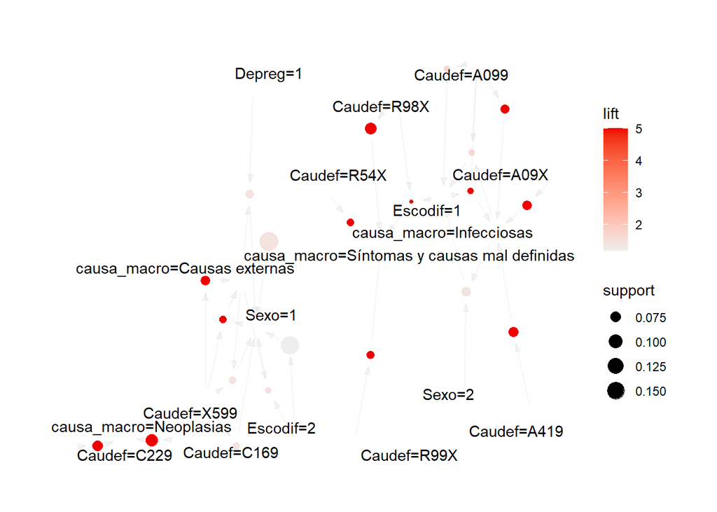

[output not shown]

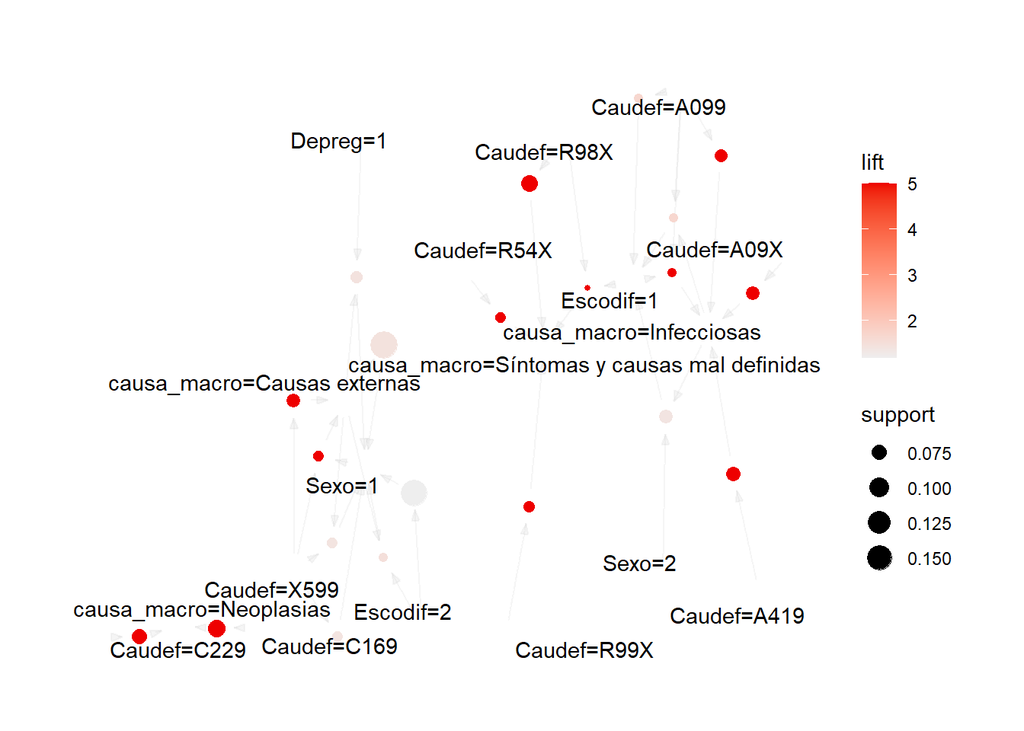

[output not shown]

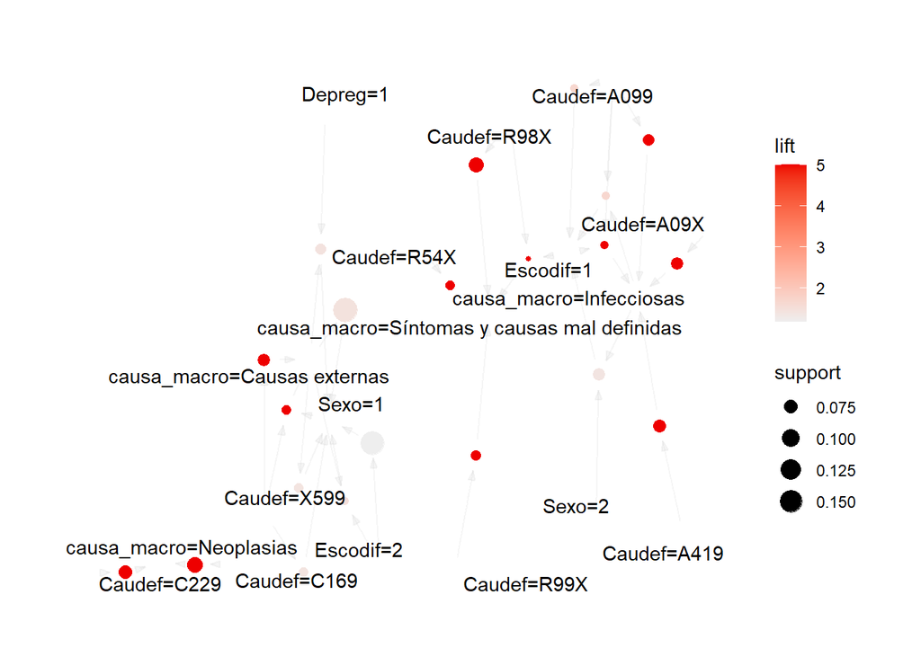

```
##
## Resumen Modelo 1:
```

```
## set of 564 rules
##
## rule length distribution (lhs + rhs):sizes
##   2   3   4
## 139 304 121
##
##    Min. 1st Qu.  Median    Mean 3rd Qu.    Max.
##   2.000   3.000   3.000   2.968   3.000   4.000
##
## summary of quality measures:
##     support          confidence        coverage            lift
##  Min.   :0.01003   Min.   :0.5004   Min.   :0.01026   Min.   : 0.8409
##  1st Qu.:0.01331   1st Qu.:0.5657   1st Qu.:0.01836   1st Qu.: 1.0971
##  Median :0.01882   Median :0.6535   Median :0.02718   Median : 1.3519
##  Mean   :0.02604   Mean   :0.7272   Mean   :0.03871   Mean   : 2.4102
##  3rd Qu.:0.03035   3rd Qu.:0.9129   3rd Qu.:0.04470   3rd Qu.: 5.0000
##  Max.   :0.25842   Max.   :1.0000   Max.   :0.50793   Max.   :10.5271
##      count
##  Min.   : 2092
##  1st Qu.: 2776
##  Median : 3925
##  Mean   : 5430
##  3rd Qu.: 6330
##  Max.   :53890
##
## mining info:
##           data ntransactions support confidence
##  transacciones        208535    0.01        0.5
##                                                                                  call
##  apriori(data = transacciones, parameter = list(supp = 0.01, conf = 0.5, minlen = 2))
```

```
##
## Resumen Modelo 2:
```

```
## set of 21 rules
##
## rule length distribution (lhs + rhs):sizes
##  2  3
## 13  8
##
##    Min. 1st Qu.  Median    Mean 3rd Qu.    Max.
##   2.000   2.000   2.000   2.381   3.000   3.000
##
## summary of quality measures:
##     support          confidence        coverage            lift
##  Min.   :0.05111   Min.   :0.7025   Min.   :0.05111   Min.   :1.177
##  1st Qu.:0.05661   1st Qu.:0.8432   1st Qu.:0.06089   1st Qu.:1.441
##  Median :0.06097   Median :1.0000   Median :0.06781   Median :5.000
##  Mean   :0.07296   Mean   :0.9221   Mean   :0.08185   Mean   :3.478
##  3rd Qu.:0.06936   3rd Qu.:1.0000   3rd Qu.:0.07398   3rd Qu.:5.000
##  Max.   :0.17201   Max.   :1.0000   Max.   :0.23667   Max.   :5.000
##      count
##  Min.   :10659
##  1st Qu.:11805
##  Median :12714
##  Mean   :15215
##  3rd Qu.:14463
##  Max.   :35870
##
## mining info:
##           data ntransactions support confidence
##  transacciones        208535    0.05        0.7
##                                                                                  call
##  apriori(data = transacciones, parameter = list(supp = 0.05, conf = 0.7, minlen = 2))
```

```
##
## Resumen Modelo 3:
```

```
## set of 120 rules
##
## rule length distribution (lhs + rhs):sizes
##  2  3  4
## 32 72 16
##
##    Min. 1st Qu.  Median    Mean 3rd Qu.    Max.
##   2.000   2.000   3.000   2.867   3.000   4.000
##
## summary of quality measures:
##     support          confidence        coverage            lift
##  Min.   :0.02005   Min.   :0.6530   Min.   :0.02063   Min.   : 1.097
##  1st Qu.:0.02469   1st Qu.:0.8278   1st Qu.:0.02794   1st Qu.: 1.463
##  Median :0.03053   Median :1.0000   Median :0.03393   Median : 5.000
##  Mean   :0.03846   Mean   :0.9062   Mean   :0.04360   Mean   : 3.562
##  3rd Qu.:0.04268   3rd Qu.:1.0000   3rd Qu.:0.04699   3rd Qu.: 5.000
##  Max.   :0.17201   Max.   :1.0000   Max.   :0.23667   Max.   :10.514
##      count
##  Min.   : 4181
##  1st Qu.: 5148
##  Median : 6366
##  Mean   : 8020
##  3rd Qu.: 8900
##  Max.   :35870
##
## mining info:
##           data ntransactions support confidence
##  transacciones        208535    0.02       0.65
##                                                                                   call
##  apriori(data = transacciones, parameter = list(supp = 0.02, conf = 0.65, minlen = 2))
```

## 🧠 Análisis de Resultados del Algoritmo Apriori

### ✅ Coherencia de los Resultados

Los resultados obtenidos mediante el algoritmo Apriori aplicado al conjunto de datos de defunciones son coherentes. Se utilizaron tres modelos con diferentes combinaciones de soporte y confianza, lo que permitió obtener conjuntos de reglas variados y contrastar su utilidad. Las reglas encontradas presentan patrones lógicos y permiten identificar relaciones relevantes entre variables demográficas y causas de muerte, lo cual es valioso para generar conocimiento y apoyar decisiones de salud pública.

### 📊 ¿Qué es el Lift?

El **lift** mide cuánto más probable es que se presente una consecuencia (RHS) dado un antecedente (LHS), en comparación con lo que se esperaría por azar.

- Un **lift > 1** indica una asociación positiva.
- Cuanto **mayor sea el lift**, más fuerte es la asociación.
- Un **lift cercano a 1** indica independencia.

**Ejemplo**: Si una regla tiene un lift de 2.5, quiere decir que la combinación de condiciones tiene 2.5 veces más probabilidad de generar el resultado que si ocurriera de forma independiente.

### ⚙️ Resumen de Modelos Apriori Aplicados

#### 🔧 Modelo 1 (564 reglas)

- **Soporte mínimo**: 0.01
- **Confianza mínima**: 0.5
- **Tamaño de reglas**: 139 de largo 2, 304 de largo 3, 121 de largo 4
- **Lift promedio**: 2.41 (máximo: 10.52)
- **Confianza promedio**: 0.73
- **Soporte promedio**: 0.026
- Este modelo genera muchas reglas con buena confianza y diversidad en el tamaño de las reglas. Es útil para análisis exploratorios más amplios.

#### 🔧 Modelo 2 (21 reglas)

- **Soporte mínimo**: 0.05
- **Confianza mínima**: 0.7
- **Tamaño de reglas**: 13 de largo 2, 8 de largo 3
- **Lift promedio**: 3.47 (máximo: 5.00)
- **Confianza promedio**: 0.92
- **Soporte promedio**: 0.073
- Este modelo es el más preciso: pocas reglas, pero todas con muy alta calidad. Ideal para aplicaciones donde se requiere máxima certeza.

#### 🔧 Modelo 3 (120 reglas)

- **Soporte mínimo**: 0.02
- **Confianza mínima**: 0.65
- **Tamaño de reglas**: 32 de largo 2, 72 de largo 3, 16 de largo 4
- **Lift promedio**: 3.56 (máximo: 10.51)
- **Confianza promedio**: 0.91
- **Soporte promedio**: 0.038
- Este modelo es un buen compromiso entre cantidad de reglas y calidad, con reglas más variadas y lift bastante elevado.

## 📈 Visualización de Reglas con arulesViz

```r
library(arulesViz)

# Visualización gráfica del modelo 2 (modelo seleccionado)
plot(modelo2, method = "graph", engine = "htmlwidget")
```

[interactive chart not shown]